# Comparing prioritization methods

### 3.2 Quantitative performance

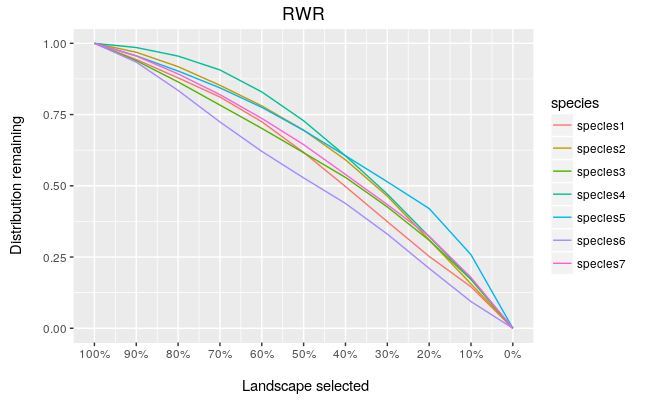

```r
# Reclassify rasters
reclass_raster <- function(x, rcl) {

   assert_that(inherits(x, "RasterLayer"),
               inherits(rcl, "data.frame"),
               all(names(rcl) == c("from", "to", "value")))

  raster_rcl <- raster::reclassify(x, rcl, include.lowest = TRUE)
  raster_rcl <- ratify(raster_rcl)
  rat_rcl <- levels(raster_rcl)[[1]]
  rat_rcl$status <- rcl$value
  levels(raster_rcl) <- rat_rcl
  return(raster_rcl)
}
zonal_stats <- function(zonal_raster, values_stack, rcl, method) {
  rcl_raster <- reclass_raster(zonal_raster, rcl)
  rcl_zonal <- as.data.frame(raster::zonal(values_stack, rcl_raster, fun = 'sum'))
  # Manually add zone 0, in which nothing has been gained yet
  data_row <- rep(0, raster::nlayers(values_stack) + 1)
  names(data_row) <- c("zone", names(values_stack))
  rcl_zonal <- rbind(rcl_zonal, as.data.frame(t(data_row)))
  rcl_zonal <- rcl_zonal %>%
    # Sort by zone, Zone 1 = 100-90% ... Zone 10 = 10-0% of the landscape
    arrange(zone) %>%
    # Gather into long format keeping zone intact
    gather(species, value, -zone) %>%
    group_by(species) %>%
    # Count cumulative value for distribution sum, that is zone1 + zone2 + ... + zone10
    # Then take the inverse of this, which is 1 -  dsum to show distribution remaining
    mutate(dsum = cumsum(value),
           drem = 1 - dsum) %>%
    ungroup() %>%
    # Finally, calculate mean distribution remaining per zone
    group_by(zone) %>%
    mutate(min_drem = min(drem),
           mean_drem = mean(drem),
           max_drem = max(drem),
           method = method)
  return(rcl_zonal)
}
# Reclassification table
rcl <- data.frame(from = seq(0, .9, 0.1),
                  to = seq(0.1, 1.0, 0.1),
                  value = 1:10)
rwr_zonal <- zonal_stats(rwr_rank, sp_rasters_normalized, rcl, "RWR")
abf_zonal <- zonal_stats(abf_rank, sp_rasters_normalized, rcl, "ABF")
caz_zonal <- zonal_stats(caz_rank, sp_rasters_normalized, rcl, "CAZ")
mcp_ilp_zonal <- zonal_stats(mcp_ilp_hier, sp_rasters_normalized, rcl, "ILP")
# Bind all zonal stats together
all_zonal <- dplyr::bind_rows(rwr_zonal, abf_zonal, caz_zonal, mcp_ilp_zonal) %>%
  dplyr::select(zone, mean_drem, method)
ggplot(rwr_zonal, aes(x = zone, y = drem, color = species)) + geom_line() + ggtitle("RWR") +
  ylab("Distribution remaining\n") + xlab("\n Landscape selected") +
  scale_x_continuous(breaks = 0:10, labels = paste0(seq(100, 0, -10), "%"))
```

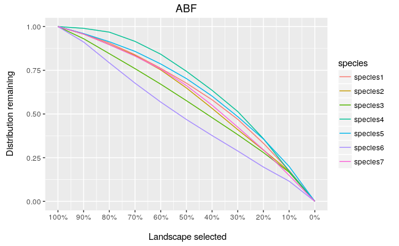

```r
ggplot(abf_zonal, aes(x = zone, y = drem, color = species)) + geom_line() + ggtitle("ABF") +
  ylab("Distribution remaining\n") + xlab("\n Landscape selected") +
  scale_x_continuous(breaks = 0:10, labels = paste0(seq(100, 0, -10), "%"))
```

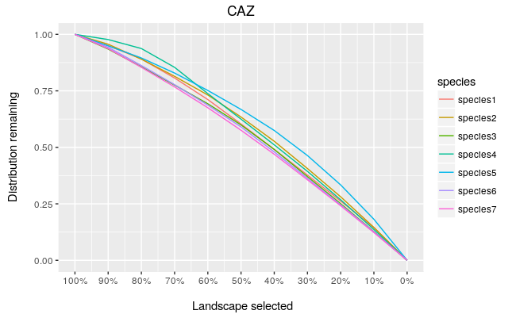

```r
ggplot(caz_zonal, aes(x = zone, y = drem, color = species)) + geom_line() + ggtitle("CAZ") +
  ylab("Distribution remaining\n") + xlab("\n Landscape selected") +
  scale_x_continuous(breaks = 0:10, labels = paste0(seq(100, 0, -10), "%"))
```

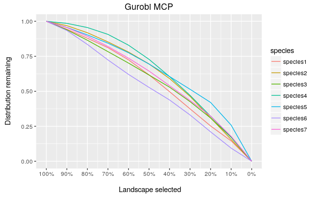

```r
ggplot(mcp_ilp_zonal, aes(x = zone, y = drem, color = species)) + geom_line() +
  ggtitle("Gurobi MCP") + ylab("Distribution remaining\n") + xlab("\n Landscape selected") +
  scale_x_continuous(breaks = 0:10, labels = paste0(seq(100, 0, -10), "%"))
```

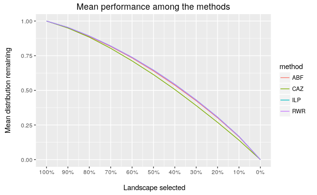

```r
ggplot(all_zonal, aes(x = zone, y = mean_drem, color = method)) + geom_line() +
  ylab("Mean distribution remaining\n") + xlab("\n Landscape selected") +
  ggtitle("Mean performance among the methods") +
  scale_x_continuous(breaks = 0:10, labels = paste0(seq(100, 0, -10), "%"))
```

What is striking here, is that there is very little difference between the methods. CAZ - as expected - has on average a little lower performance, others are very similar.

## 4. Literature cited

- Albuquerque, F. S., & Beier, P. (2015). Rarity-Weighted Richness: A Simple and Reliable Alternative to Integer Programming and Heuristic Algorithms for Minimum Set and Maximum Coverage Problems in Conservation Planning. Plos One, 10(3), e0119905. http://doi.org/10.1371/journal.pone.0119905
- Arponen, A., Cabeza, M., Eklund, J., Kujala, H., & Lehtomaki, J. (2010). Costs of integrating economics and conservation planning. Conservation Biology, 24(5), 1198–204. http://doi.org/10.1111/j.1523-1739.2010.01539.x
- Beyer, H. L., Dujardin, Y., Watts, M. E., & Possingham, H. P. (2016). Solving conservation planning problems with integer linear programming. Ecological Modelling, 328, 14–22. http://dx.doi.org/10.1016/j.ecolmodel.2016.02.005
- Camm, J. D., Polasky, S., Solow, A., & Csuti, B. (1996). A note on optimal algorithms for reserve site selection. Biological Conservation, 78(3), 353–355. http://doi.org/10.1016/0006-3207(95)00132-8
- Laitila, J., & Moilanen, A. (2012). Use of many low-level conservation targets reduces high-level conservation performance. Ecological Modelling, 247, 40–47. http://doi.org/10.1016/j.ecolmodel.2012.08.010
- Moilanen, A. (2007). Landscape Zonation, benefit functions and target-based planning: unifying reserve selection strategies. Biological Conservation, 134, 571–579. http://dx.doi.org/10.1016/j.biocon.2006.09.008
- Moilanen, A., & Arponen, A. (2011). Setting conservation targets under budgetary constraints. Biological Conservation, 144(1), 650–653. http://doi.org/10.1016/j.biocon.2010.09.006
- Underhill, L. G. 1994. Optimal and suboptimal reserve selection algorithms. Biological Conservation 70:85–87. http://dx.doi.org/10.1016/0006-3207(94)90302-6